# For Loop, Apply, Boostrap Example using our friend Iris

Marguerite

2020-01-24

In this example, letʻs suppose we want to get a 95% Confidence Interval around the mean using Bootsrap (sampling with replacement). For the data, letʻs use petal length from setosa:

```r
petalL <- iris[iris$Species=="setosa","Petal.Length"]
```

The pseudo code for this problem might look like:

1. generate sample for petalL
2. get mean
3. generate 100 samples
4. generate 100 means (100 bootstraps)
5. Calculate 95% CI from distribution of sampled means, compare to true mean

# Generating a sample with replacement, calculate mean

```r
sample( petalL, replace=T )
```

```
##  [1] 1.6 1.5 1.4 1.0 1.4 1.5 1.4 1.5 1.4 1.6 1.3 1.6 1.7 1.5
## [15] 1.3 1.5 1.6 1.5 1.3 1.5 1.5 1.5 1.4 1.3 1.2 1.4 1.4 1.7
## [29] 1.3 1.5 1.5 1.4 1.1 1.2 1.2 1.4 1.0 1.5 1.6 1.9 1.3 1.6
## [43] 1.7 1.6 1.4 1.4 1.5 1.0 1.3 1.4
```

```r
mean( sample( petalL, replace=T ) )
```

```
## [1] 1.45
```

# How to generate 100 means? So many ways

This problem can actually be broken down further (see pseudocode above) but in essence it involves the calculations plus storage of the objects. What type of *bucket* do we want to store our values in?

## Create a list

```r
allmeans <- vector("list", 100)
```

## Fill it using a for loop

```r
for ( i in 1:100) {

    allmeans[i] <- mean( sample( petalL, replace=T ) )
}
head(allmeans)
```

```
## [[1]]
## [1] 1.442
##
## [[2]]
## [1] 1.434
##
## [[3]]
## [1] 1.468
##
## [[4]]
## [1] 1.466
##
## [[5]]
## [1] 1.464
##
## [[6]]
## [1] 1.436
```

## Does it work if our bucket is a vector?

```r
allmeans <- vector()  # you may need to do vector(length=100)
for ( i in 1:100) {

    allmeans[i] <- mean( sample( petalL, replace=T ) )
}
head(allmeans)
```

```
## [1] 1.472 1.450 1.470 1.476 1.456 1.424
```

# Actually, letʻs not try to do too many steps at once.

## Baby steps: take a sample, get the mean

```r
x <- sample(petalL, replace=T)
mean(x)
```

```
## [1] 1.472
```

## Use lapply to get 100 samples

`lapply` operates over a list or a vector, and runs a function on each element. Our function is `sample` and our vector is 50, the size of the sample we want, repeated 100 times for our 100 samples. We give the other arguments to `sample` as additional arguments. (Showing first 6):

```r
lapply( rep(50,100), sample, x=petalL, replace=T)
samples <- lapply ( rep(50, 100), sample, x=petalL, replace=T)
```

```
## [[1]]
##  [1] 1.6 1.5 1.4 1.5 1.5 1.5 1.4 1.4 1.4 1.7 1.4 1.6 1.3 1.4
## [15] 1.0 1.4 1.7 1.5 1.5 1.5 1.4 1.5 1.3 1.5 1.5 1.5 1.4 1.3
## [29] 1.5 1.9 1.4 1.4 1.6 1.7 1.3 1.6 1.4 1.4 1.5 1.4 1.4 1.4
## [43] 1.1 1.1 1.4 1.6 1.5 1.6 1.3 1.3
##
## [[2]]
##  [1] 1.5 1.5 1.4 1.7 1.6 1.3 1.3 1.5 1.5 1.4 1.1 1.4 1.2 1.5
## [15] 1.6 1.5 1.4 1.7 1.5 1.3 1.4 1.3 1.3 1.6 1.4 1.3 1.2 1.6
## [29] 1.5 1.7 1.5 1.6 1.9 1.7 1.4 1.3 1.5 1.3 1.6 1.6 1.5 1.5
## [43] 1.6 1.1 1.6 1.3 1.6 1.5 1.7 1.5
##
## [[3]]
##  [1] 1.6 1.5 1.4 1.6 1.3 1.4 1.4 1.4 1.4 1.4 1.6 1.5 1.6 1.6
## [15] 1.5 1.9 1.4 1.4 1.4 1.0 1.3 1.6 1.4 1.3 1.6 1.3 1.4 1.5
## [29] 1.7 1.3 1.5 1.6 1.5 1.3 1.3 1.5 1.2 1.5 1.0 1.5 1.5 1.6
## [43] 1.5 1.4 1.6 1.7 1.1 1.0 1.6 1.3
##
## [[4]]
##  [1] 1.9 1.6 1.3 1.5 1.6 1.5 1.4 1.4 1.1 1.4 1.4 1.7 1.5 1.6
## [15] 1.5 1.3 1.5 1.2 1.5 1.9 1.5 1.1 1.6 1.4 1.4 1.4 1.3 1.4
## [29] 1.6 1.6 1.4 1.5 1.5 1.4 1.5 1.4 1.5 1.6 1.1 1.3 1.4 1.5
## [43] 1.2 1.4 1.5 1.3 1.4 1.5 1.6 1.5
##
## [[5]]
##  [1] 1.5 1.4 1.5 1.4 1.4 1.4 1.7 1.5 1.3 1.4 1.5 1.6 1.7 1.3
## [15] 1.3 1.3 1.6 1.5 1.6 1.2 1.4 1.4 1.4 1.2 1.3 1.4 1.3 1.5
## [29] 1.5 1.5 1.6 1.6 1.5 1.4 1.3 1.6 1.3 1.6 1.6 1.3 1.4 1.5
## [43] 1.5 1.3 1.4 1.6 1.4 1.3 1.6 1.4
##
## [[6]]
##  [1] 1.4 1.3 1.5 1.3 1.4 1.4 1.5 1.7 1.6 1.5 1.2 1.6 1.3 1.1
## [15] 1.5 1.5 1.4 1.3 1.6 1.4 1.6 1.3 1.5 1.4 1.4 1.2 1.4 1.1
## [29] 1.4 1.6 1.6 1.2 1.5 1.7 1.3 1.5 1.3 1.4 1.4 1.4 1.5 1.0
## [43] 1.4 1.5 1.5 1.5 1.5 1.4 1.3 1.5
```

Can we just take the mean? What is the problem?

```r
mean(samples)
```

```
## [1] NA
```

`samples` is a list, so use `lapply` to get means of each sample. This works (just showing first 6):

```r
lapply (samples, mean)
```

```
## [[1]]
## [1] 1.446
##
## [[2]]
## [1] 1.46
##
## [[3]]
## [1] 1.49
##
## [[4]]
## [1] 1.512
##
## [[5]]
## [1] 1.488
##
## [[6]]
## [1] 1.434
```

So save it:

```r
allmeans <- lapply (samples, mean)
```

Our final code using `lapply` can be condensed to 2 lines, not too bad:

```r
samples <- lapply ( rep(50, 100), sample, x=petalL, replace=T)
allmeans <- lapply(samples, mean)
head(allmeans)
```

```
## [[1]]
## [1] 1.498
##
## [[2]]
## [1] 1.5
##
## [[3]]
## [1] 1.478
##
## [[4]]
## [1] 1.44
##
## [[5]]
## [1] 1.474
##
## [[6]]
## [1] 1.45
```

## Another way is to define the function within lapply:

Note here that x is just a dummy variable. It takes on a single value of the input list, but we donʻt actually use it

```r
lapply ( rep(50, 100), function(x) { mean(sample( petalL, replace=T))})
```

```
## [[1]]
## [1] 1.456
##
## [[2]]
## [1] 1.496
##
## [[3]]
## [1] 1.518
##
## [[4]]
## [1] 1.542
##
## [[5]]
## [1] 1.464
##
## [[6]]
## [1] 1.466
```

Now try sapply on any/all of the above. For example:

```r
sapply ( rep(50, 100), function(x) { mean(sample( petalL, replace=T))})
```

```
##   [1] 1.434 1.442 1.444 1.472 1.434 1.456 1.428 1.472 1.472
##  [10] 1.432 1.486 1.478 1.460 1.442 1.458 1.428 1.448 1.454
##  [19] 1.466 1.444 1.442 1.458 1.468 1.420 1.452 1.506 1.466
##  [28] 1.438 1.448 1.506 1.466 1.478 1.470 1.512 1.448 1.466
##  [37] 1.460 1.444 1.470 1.462 1.452 1.434 1.468 1.472 1.488
##  [46] 1.474 1.406 1.470 1.494 1.498 1.410 1.450 1.400 1.432
##  [55] 1.430 1.480 1.462 1.486 1.428 1.456 1.486 1.452 1.454
##  [64] 1.442 1.470 1.462 1.498 1.448 1.440 1.418 1.498 1.446
##  [73] 1.492 1.402 1.418 1.458 1.468 1.484 1.448 1.466 1.522
##  [82] 1.448 1.460 1.438 1.438 1.474 1.476 1.466 1.490 1.480
##  [91] 1.460 1.476 1.428 1.454 1.448 1.486 1.460 1.434 1.456
## [100] 1.458
```

See what they mean about “pretty” output? sapply returns a vector or a matrix if it can.

# Back to our confidence interval example:

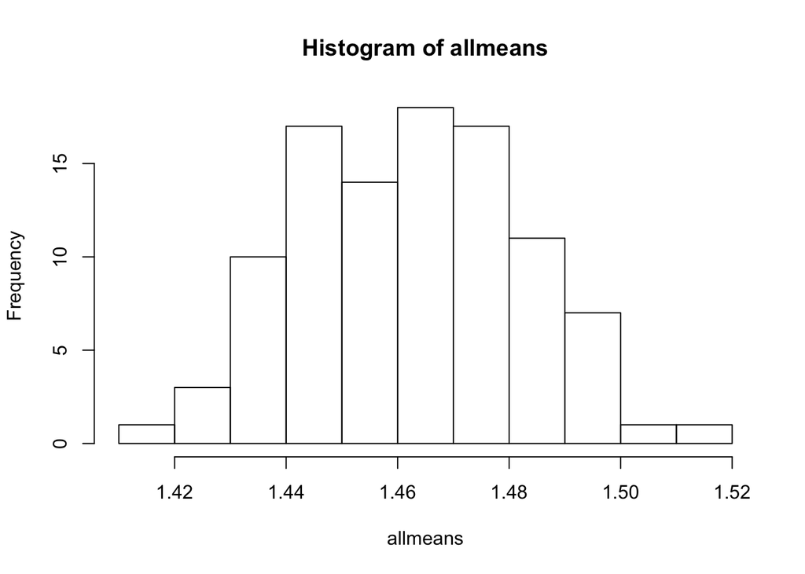

```r
samples <- lapply ( rep(50, 100), sample, x=petalL, replace=T)
allmeans <- sapply(samples, mean)

hist(allmeans)
```

This is a bit blocky, so letʻs plot more bins:

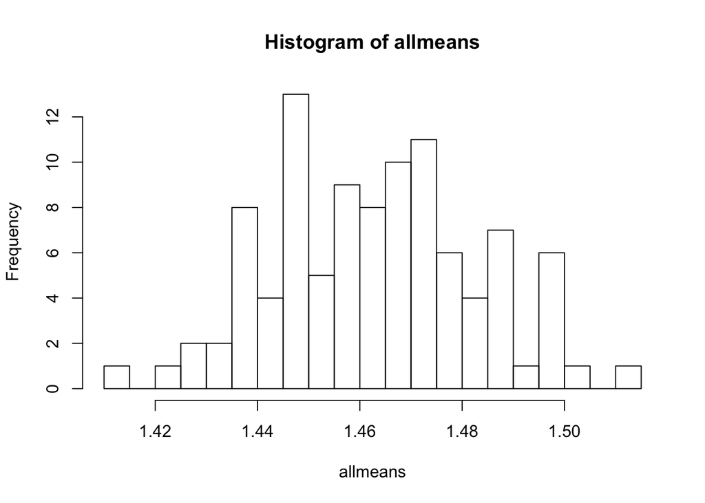

```r
hist(allmeans, breaks=20)
```

The 95% confidence interval is where 95% of the sampled means falls. So if we sort them and draw a line at the 2.5 percentile, and the 97.5 percentile, weʻll see the 95%CI

```r
ss <- sort(allmeans)
ss[3] ## lower 2.5% only 100, so round to 3
```

```
## [1] 1.428
```

```r
ss[97] ## upper 97.5%, round to 97
```

```
## [1] 1.498
```

You could do more samples to cleanly separate 2.5 and 97.5%

## Plot with bells and whistles:

- Plot the true mean of petalL in red, CI in blue
- Add labels to plot
- Arrows to indicate 95% CI

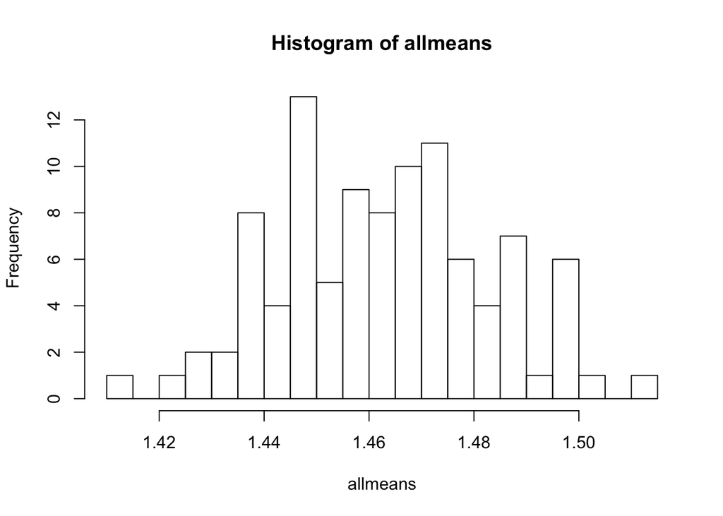

[figure not shown]

```r
h <- hist(allmeans, breaks=20)

abline( v=mean(petalL), col="red", lwd=3)
abline( v=ss[3], col="blue", lwd=3)
abline( v=ss[97], col="blue", lwd=3)
text(mean(petalL), 1, "True Mean", pos=4, col="red", cex=2)
text(ss[3], 10, "Lower 2.5%", pos=4, col="blue")
text(ss[97], 10, "Upper 97.5%", pos=2, col="blue")
arrows(ss[3], 9.75, ss[97], 9.75, lty=2, code=3, col="blue")
text(mean(petalL), 10, "95% CI", col="blue")
```

The mean is mean(petalL), and the 95% CI is (ss[3], ss[97])

We can also plot the “density” of the means using a kernal density method assuming Gaussian kernal densities (Normal)

```r
density(allmeans)
```

```
##
## Call:
##  density.default(x = allmeans)
##
## Data: allmeans (100 obs.);   Bandwidth 'bw' = 0.007158
##
##        x               y
##  Min.   :1.391   Min.   : 0.006293
##  1st Qu.:1.427   1st Qu.: 0.599295
##  Median :1.463   Median : 4.915655
##  Mean   :1.463   Mean   : 6.892147
##  3rd Qu.:1.499   3rd Qu.:13.160446
##  Max.   :1.535   Max.   :17.800370
```

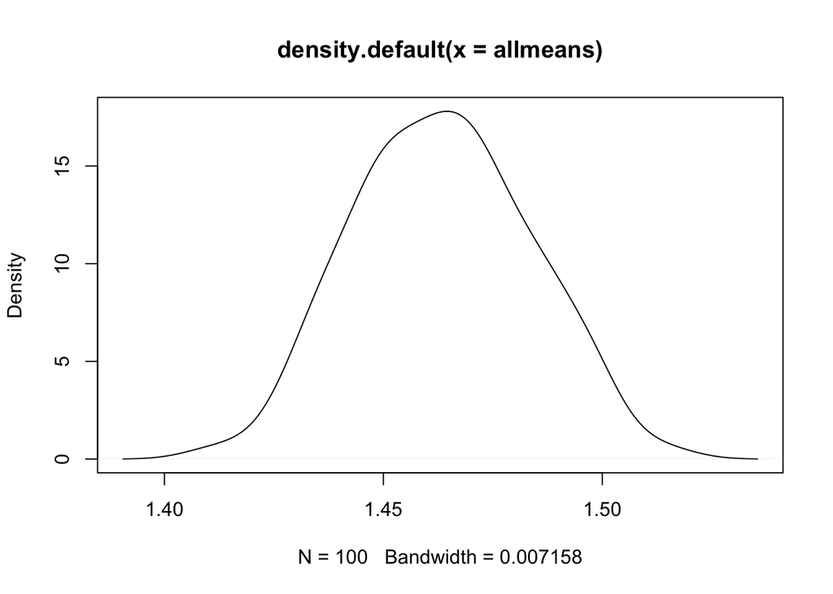

```r
plot(density(allmeans))
```

What is the object returned from `density`? Check using structure function:

```r
d <- density(allmeans)
str(d)
```

```
## List of 7
##  $ x        : num [1:512] 1.39 1.39 1.39 1.39 1.39 ...
##  $ y        : num [1:512] 0.00629 0.00707 0.00795 0.00892 0.00998 ...
##  $ bw       : num 0.00716
##  $ n        : int 100
##  $ call     : language density.default(x = allmeans)
##  $ data.name: chr "allmeans"
##  $ has.na   : logi FALSE
##  - attr(*, "class")= chr "density"
```

It is a list with 7 elements, y is the probability density. To get the maximum height to put our labels on the graph:

```r
d <- density(allmeans)
ymax <- max(d[["y"]])  ## use to size y-axis
```

## Bells and whistles:

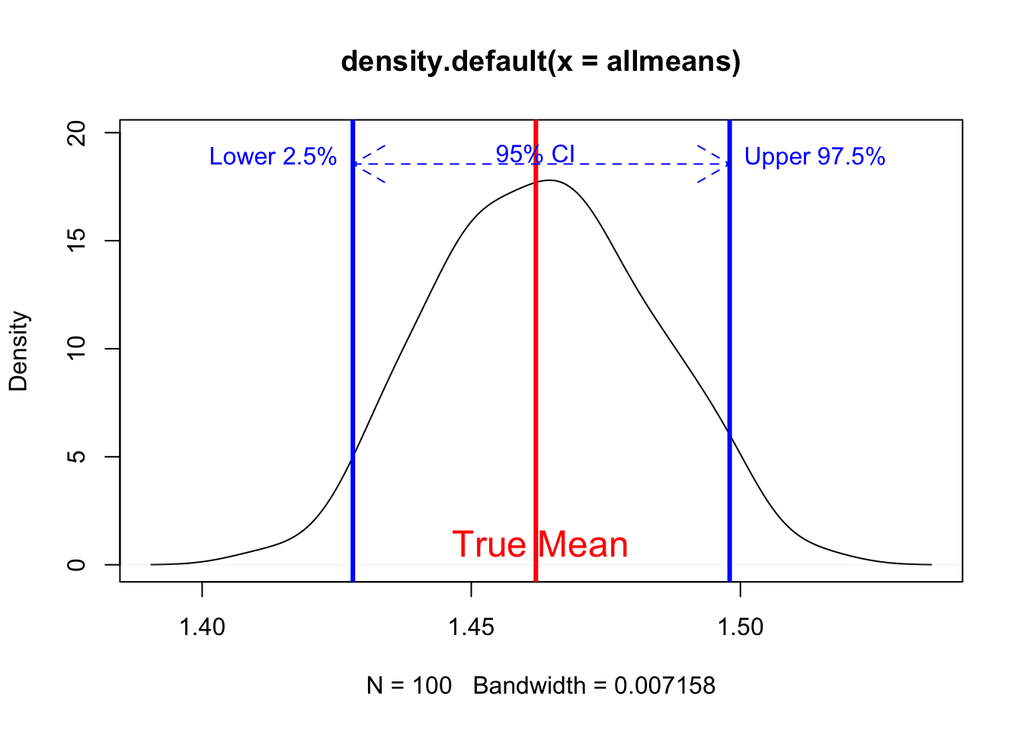

```r
plot(d, ylim=c(0, ymax+2))

abline( v=mean(petalL), col="red", lwd=3)
abline( v=ss[3], col="blue", lwd=3)
abline( v=ss[97], col="blue", lwd=3)

text(mean(petalL), 1, " True Mean", col="red", cex=1.5)
text(ss[3], ymax+1, "Lower 2.5%", pos=2, col="blue")
text(ss[97], ymax+1, "Upper 97.5%", pos=4, col="blue")
arrows(ss[3], ymax+.75, ss[97], ymax+.75, lty=2, code=3, col="blue")
text(mean(petalL), ymax+1.25, "95% CI", col="blue")
```

# R notes

- Using for loops versus lapply/sapply is a matter of personal preference, although often apply methods are faster than loops. This is because R is vectorized and has efficient methods for operating on an entire vector/list at once.
- If you must iterate the value (i.e., the value changes on each iteration and feeds into the next loop, you will have to use a for loop or a do while).
- lapply and sapply are generally interchangable but sapply will return a vector or matrix if it can. lapply always returns a list.
- Which order of operations and objects are optimal may differ bewtween a for loop strategy vs. a vectorized operation:
  - For loop: (generate sample, generate mean) x 100 -> output
  - apply method: 100 samples -> 100 means -> output
- Note that non-parametric CIʻs donʻt have to be symmetric. It depends only on the sample distribution.